# Bayes Primer

Ecological Forecasting Workshop, Cape Town, July 2025

Murray Christian

## Overview

1. Why Bayes?
2. Probability: joint, marginal and conditional
3. Bayes’ Theorem: prior, likelihood and posterior
4. Bayesian inference: a simple example
5. Bayesian workhorse: Markov Chain Monte Carlo

## Why Bayes?

Several attractive features of Bayesian inference

- flexibility: complex models can be specified easily
- intuitive: probability statements about parameters are legitimate
- uncertainty: quantified robustly, easily propagated
- iterative: estimates naturally updated given new data
- conceptual simplicity:
  $$f(\theta|y) \propto f(y|\theta)f(\theta)$$

# Probability

## Probability distributions

Assume a penguin, and assume it will be alive and of breeding age next year.

It may

- choose to breed or not, and
- choose one of colonies A, B or C as home.

We might be interested in the probability of it

1. breeding and being at colony A?
2. breeding at all? being at colony A irrespective of breeding?
3. breeding, if we know (or assume) it will be at colony A?

Different queries require different distributions, here *joint*, *marginal* and *conditional distributions*, respectively.

## Joint distribution

Next year’s *breeding status* and *colony* can each be described by a random variable:

$$X = \left\{
\begin{align}
1 & \hspace{5pt} \mbox{ if breeds } \\
0 & \hspace{5pt} \mbox{ if doesn't breed }
\end{align} \right.$$

$$Y = \left\{
\begin{align}
1 & \hspace{5pt} \mbox{ if resides at colony A } \\
2 & \hspace{5pt} \mbox{ if resides at colony B } \\
3 & \hspace{5pt} \mbox{ if resides at colony C }
\end{align} \right.$$

A **joint distribution** for $X$ and $Y$ specifies $\text{Pr}(X=x,Y=y)$ for all pairs $(x,y)$.

For example,

|  | Y = 1 | Y = 2 | Y = 3 |
| --- | --- | --- | --- |
| **X = 0** | 0.15 | 0.05 | 0.2 |
| **X = 1** | 0.3 | 0.1 | 0.2 |

So $\text{Pr}(X = 1, Y = 2) = 0.1$ is the probability of breeding at colony B, *etc*.

## Marginal distributions

The joint distribution for $X$ and $Y$ implies a distribution for each variable on it’s own, called the **marginal distribution**.

For example, the marginal for $X$ is given by two values $\text{Pr}(X=x)$ for $x=0,1$.

These are obtained by “summing out” the other variable, for example

$$\text{Pr}(X = x) = \text{Pr}(X = x, Y = 1) + \text{Pr}(X = x, Y = 2) + \text{Pr}(X = x, Y = 3).$$

The marginal distributions live “on the margins” of the joint

|  | Y = 1 | Y = 2 | Y = 3 |  |
| --- | --- | --- | --- | --- |
| **X = 0** | 0.15 | 0.05 | 0.2 | 0.4 |
| **X = 1** | 0.3 | 0.1 | 0.2 | 0.6 |
|  | 0.45 | 0.15 | 0.4 |  |

## Joint and marginal: continuous case

- In our penguin example, $X$ and $Y$ are discrete.
- For continuous $X$ and $Y$, the joint and marginal distributions are determined by *probability density functions*.
  - joint density $f(x,y)$,
  - marginal densities are obtained by “integrating out” the other variable(s)
  - for example,
    $$f(y) = \int f(x,y)dx$$

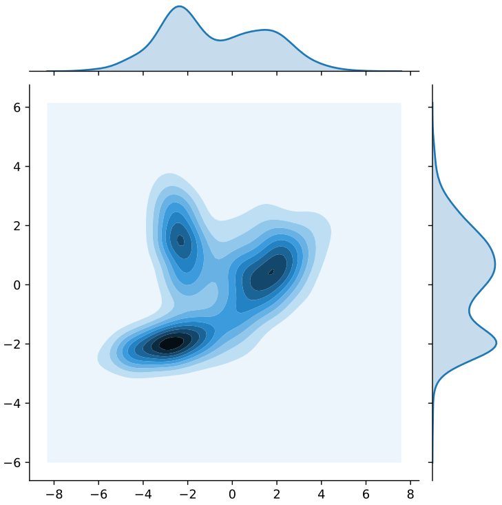

## Conditional distributions

Conditional distributions arise when we know (or assume) some extra information.

- What are the probabilities the penguin does/doesn’t breed if it goes to colony B?

- |  | Y = 1 | Y = 2 | Y = 3 |
  | --- | --- | --- | --- |
  | **X = 0** | 0.15 | 0.05 | 0.2 |
  | **X = 1** | 0.3 | 0.1 | 0.2 |

- So, given colony B ($Y=2$), breeding $(X=1)$ is twice as likely as not.
- Intuitively, probabilities should be $2/3$ breeds and $1/3$ doesn’t breed.
- How do we get $2/3$ and $1/3$ from $0.1$ and $0.05$?
- Normalise: divide $0.1$ and $0.05$ by their sum
  $$\frac{2}{3} = \frac{0.1}{0.1 + 0.05} \hspace{5pt} \text{ & } \hspace{5pt} \frac{1}{3} = \frac{0.05}{0.1 + 0.05}$$

The *conditional distribution is joint divided by marginal*:

$$\text{Pr}(X=x|Y=2) = \frac{\text{Pr}(X=x, Y=2)}{\text{Pr}(Y=2)} \hspace{15pt} \text{ for } x = 0, 1.$$

## Conditional distributions

In general, conditional distributions are “joint divided by marginal”.

- In the continuous setting this applies to the densities.
- $$f(x|y) = \frac{f(x,y)}{f(y)} \hspace{5pt} \text{ and } \hspace{5pt} f(y|x) = \frac{f(x,y)}{f(x)}$$
- Geometrically, conditional densities are “rescaled slices” of the joint.
  - e.g $f(y|x=-2)$ and $f(y|x=2)$

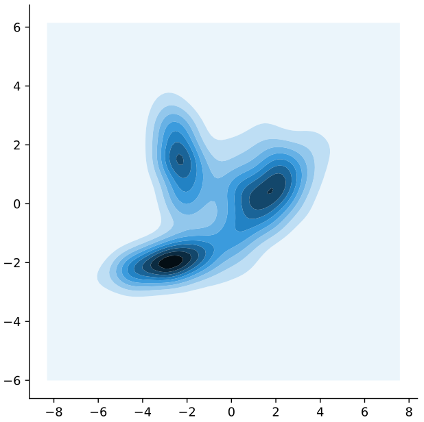

## Conditional probability caution

- ambiguity in language: consider “probability of breeding at colony A”
  - “probability of breeding *given* that it’s at colony A”
  - “probability of breeding *and* doing so at colony A”
- What’s being modelled with $f(x,y)$ vs. $f(x|y)$
  - $f(x,y)$: both $X,Y$ are modelled in the sense that there are probabilities associated with both
  - $f(x|y)$: only $X$ is being modelled, $Y$ is assumed fixed with value $y$.
- conditional probability is easily misunderstood

[figure not shown]

Thanks Maryam.

# Bayes’ Theorem

## Bayes’ Theorem

Foundation of Bayesian statistics, used to infer parameters $\theta$ from data $y$:

$$f(\theta|y) = \frac{f(y|\theta)f(\theta)}{f(y)},$$

- **prior distribution** $f(\theta)$ represents knowledge of parameters before seeing data
- **likelihood** $f(y|\theta)$ probability of data given parameters (a function of $\theta$ for fixed data $y$)
- **posterior distribution** $f(\theta|y)$ updated knowledge of parameters given observed data
- for computing the posterior, the marginal probability of the data $f(y)$ can be ignored

*Posterior is proportional to likelihood times prior*
$$f(\theta|y) \propto f(y|\theta)f(\theta)$$

## Bayes’ Theorem: proof

Bayes’ Theorem is a simple consequence of the definition of conditional probability:

$$f(\theta|y) = \frac{f(\theta, y)}{f(y)} \hspace{10pt} \text{ and } \hspace{10pt} f(y|\theta) = \frac{f(\theta, y)}{f(\theta)},$$

therefore

$$f(\theta, y) = f(\theta|y)f(y) \hspace{10pt} \text{ and } \hspace{10pt} f(\theta, y) = f(y|\theta)f(\theta),$$

so
$$f(\theta|y)f(y) = f(y|\theta)f(\theta),$$

hence

$$f(\theta|y) = \frac{f(y|\theta)f(\theta)}{f(y)}.$$

# Bayesian inference: a simple example

## Bayesian inference: a simple example

Example from McElreath *Statistical Rethinking*

What proportion of the Earth’ surface is covered in water?

**First step**: define variables and set up probability model

- one parameter $\theta$, the proportion water, $0 < \theta < 1$
- data are water/land status $y_1, \cdots, y_N$ of points randomly sampled from Earth, where
  $$Y_i = \left\{
  \begin{align}
  1 & \hspace{5pt} \mbox{ if water } \\
  0 & \hspace{5pt} \mbox{ if land }
  \end{align} \right.$$

To specify the probability model for all variables $(Y_1,\cdots, Y_N, \theta)$ we choose a likelihood and a prior:

$$\begin{align}
Y_i & \sim \text{Bernoulli}(\theta) \hspace{10pt} \text{ for } \hspace{2pt} i = 1,\cdots, N \\
\theta & \sim \text{Beta}(\alpha, \beta) \hspace{10pt} \text{ for } \alpha = \beta = 2
\end{align}$$

## Bayesian inference: a simple example

Example from McElreath *Statistical Rethinking*

What proportion of the world’s surface is covered in water?

**Second step**: using Bayes, condition on the observed data to get the posterior.

It turns out that the posterior is another Beta distribution, namely
$$\theta \sim \text{Beta}(y_* + \alpha, N - y_* + \beta)$$
where we’ve put all the data in a vector $y = (y_1, \cdots, y_N)$, and set $y_* = y_1 + \cdots + y_N$ for the total number of points over water.

For example, suppose we took $N = 10$ samples and observed $y_* = 9$ over water. With our $\text{Beta}(2,2)$ prior this gives a posterior
$$\theta \sim \text{Beta}(11, 3),$$
which has a mean of $11/14 \approx 0.79$.

*The posterior is the whole estimate in Bayes!* Explain…

## Bayesian inference: optional algebra

Here’s the math that lead us to the posterior (in case it helps).

The likelihood for one observation $y_i$ is the Bernoulli probability mass function
$$f(y_i|\theta) = \theta^{y_i}(1 - \theta)^{(1 - y_i)} = \left\{
\begin{align}
\theta & \hspace{5pt} \mbox{ if } \hspace{5pt} y_i = 1 \\
1-\theta & \hspace{5pt} \mbox{ if } \hspace{5pt} y_i = 0.
\end{align} \right.$$

We’re assuming they data are independent, so the likelihood for all observations is
$$f(y_1, \cdots, y_N|\theta) = \prod_{i=1}^Nf(y_i|\theta) = \prod_{i=1}^N\theta^{y_i}(1-\theta)^{1-y_i} = \theta^{y_*}(1- \theta)^{N - y_*},$$
where $y_* = y_1 + \cdots + y_N$ is the total number of points over water.

The prior is a Beta density

$$f(\theta) \propto \theta^{\alpha - 1}(1 - \theta)^{\beta - 1},$$
where I’ve dropped the normalising constant for the Beta distribution.

Therefore, we have

$$\begin{align}
f(\theta|y) & \propto f(y|\theta)f(\theta) \\
& \propto \theta^{y_*}(1- \theta)^{N - y_*} \cdot \theta^{\alpha - 1}(1 - \theta)^{\beta - 1} \\
& = \theta^{(y_* + \alpha)-1}(1 - \theta)^{(N - y_* + \beta)-1},
\end{align}$$
which we recognise as the (unnormalised) density for a $\text{Beta}(y_* + \alpha, N - y_* + \beta)$!

Now take a look at the interactive graphic exploring prior, likelihood and posterior for the proportion water model. To do so, open `run_apps.R`, and follow the instructions there.

## Bayesian inference: takeaways

Lessons learnt:

- the posterior is a compromise between likelihood and prior
- prior and likelihood are weighted by their certainty
- prior’s influence on posterior diminishes with increasing data (assuming non-degeneracy)

Things to note:

- the prior should **not** be constructed based on the data!

## Lessons repeated!

Here’s an example that illustrates the lessons algebraically: normal-normal conjugacy when estimating a normal mean $\mu$ from sample $y = (y_1, \cdots, y_n)$ with normal prior on $\mu$.

$$\begin{align}
Y_i & \sim \text{Normal}(\mu, \sigma^2_{data}) \hspace{10pt} \text{ for } \hspace{2pt} i = 1,\cdots, n \\
\mu & \sim \text{Normal}(\mu_{prior}, \sigma^2_{prior}) \hspace{10pt} \text{ for given prior mean and variance. }
\end{align}$$

This is another case with analytic posterior. It’s insightful to define precision

$$\tau_{prior} = 1/\sigma^2_{prior} \hspace{5pt} \mbox{ and } \hspace{5pt} \tau_{data} = 1/\sigma^2_{data}$$

Then the posterior is
$$\begin{align}
\mu & \sim \text{Normal}(\mu_{post}, \tau_{post}) \hspace{10pt} \text{ where } \\
\mu_{post} & = \left(\frac{n\tau_{data}}{n\tau_{data} + \tau_{prior}}\right) \bar{x} + \left(\frac{\tau_{prior}}{n\tau_{data} + \tau_{prior}}\right) \mu_{prior} \\
\tau_{post} & = n\tau_{data} + \tau_{prior}
\end{align}$$

# Bayesian workhorse: Markov Chain Monte Carlo

## A distribution from a sample

In most models, we can’t obtain the posterior analytically. Fortunately there is a powerful set of algorithms that draw *samples* from the posterior. Any distribution can be approximated by a sufficiently large sample from it.

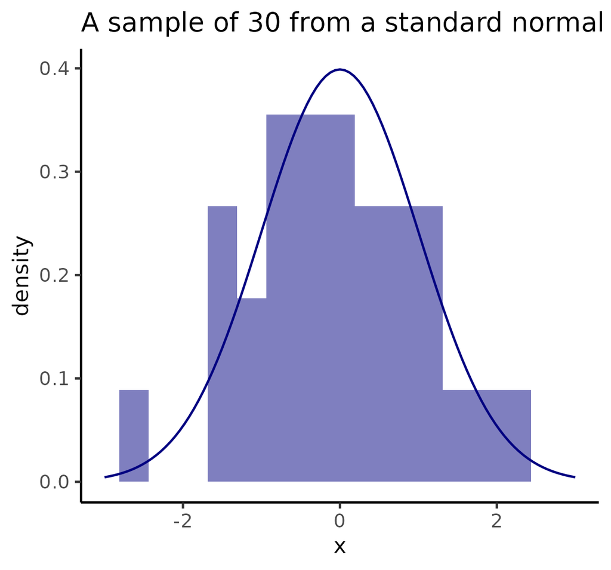

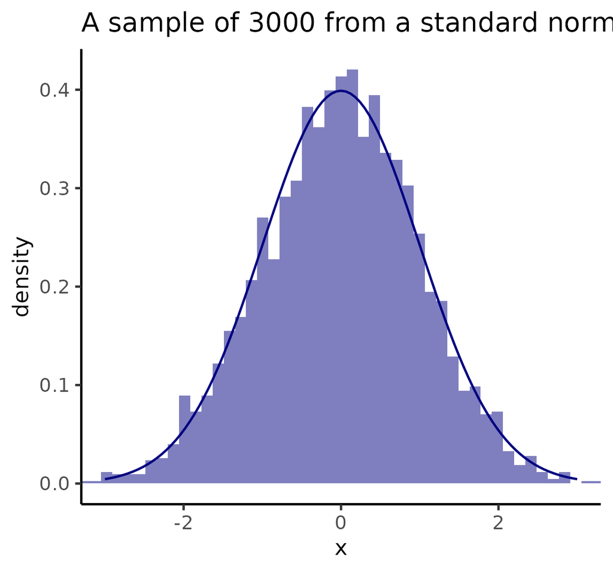

## Markov Chain Monte Carlo

Basic idea: construct a Markov chain, i.e. a sequence of draws $\theta^{(1)}, \theta^{(2)}, \theta^{(3)}, \cdots$ from a distribution, such that in the limit, they represent the distribution in a similar way to a random sample.

Look at Chi Feng’s great interactive MCMC simulation (https://chi-feng.github.io/mcmc-demo/).

Theory says that if we draw enough samples, we will get an adequate picture of the posterior. MCMC diagnostics help us to know if we have drawn enough samples.

- trace plots (looking for “hairy caterpillars”)
- effective sample sizes (sample from MCMC is not independent)
- r-hats